# Data Analysis - Red Wine

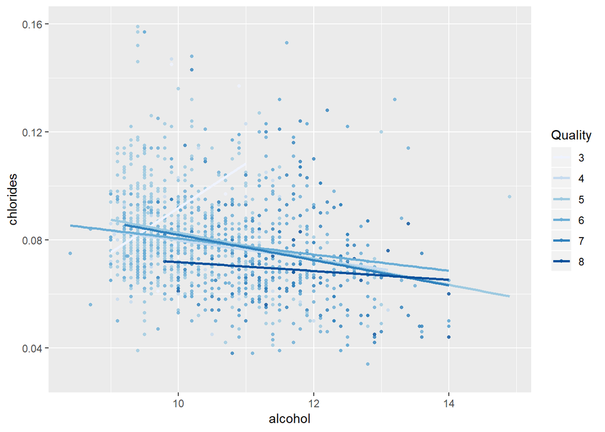

No clear relationship is observed here.

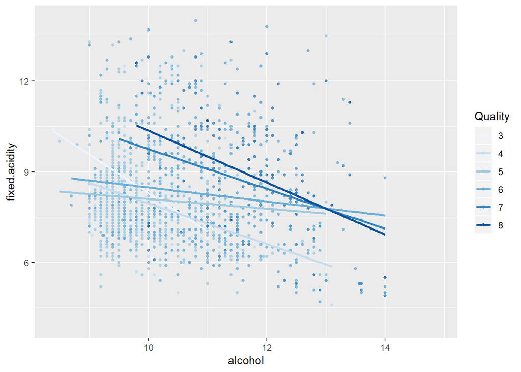

No clear relationship is observed here.

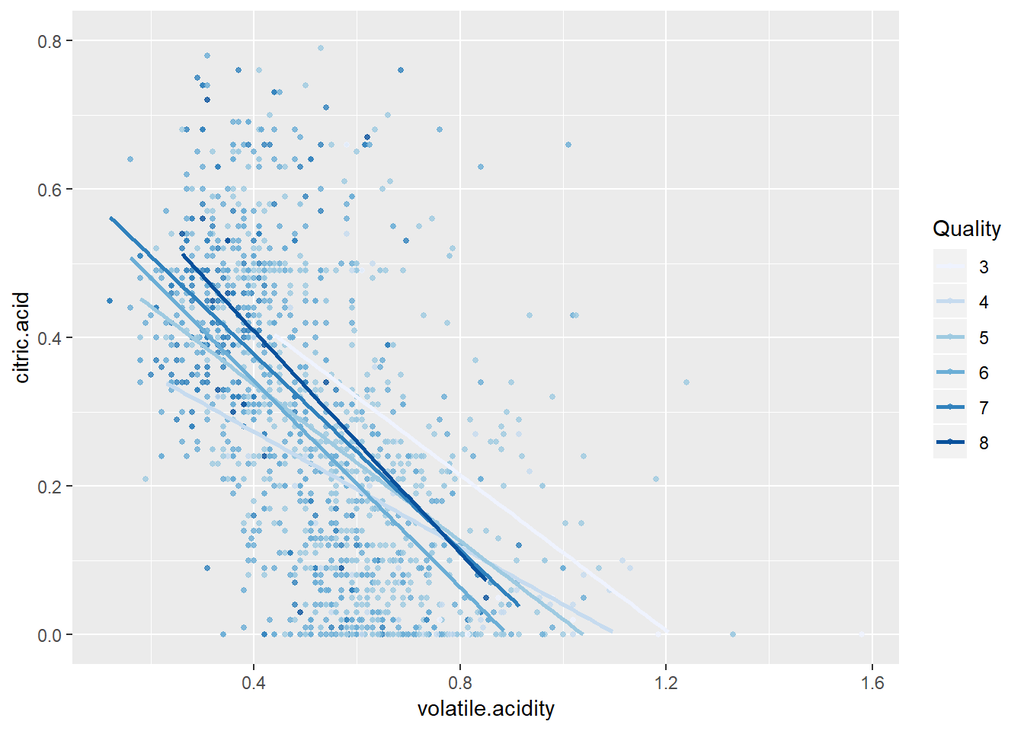

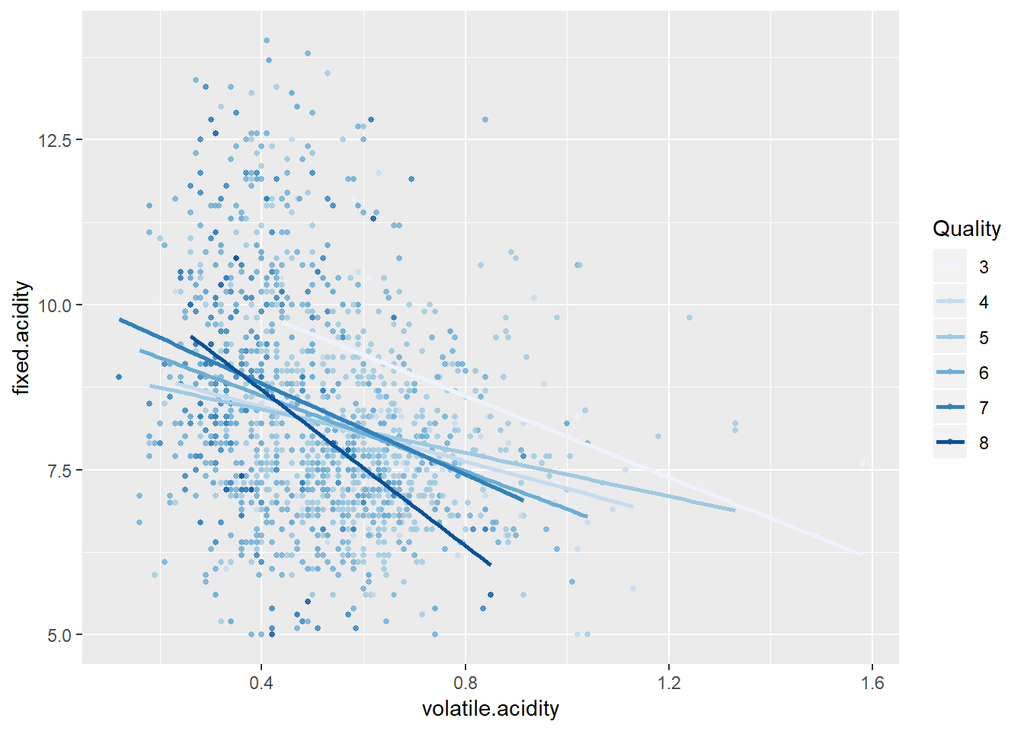

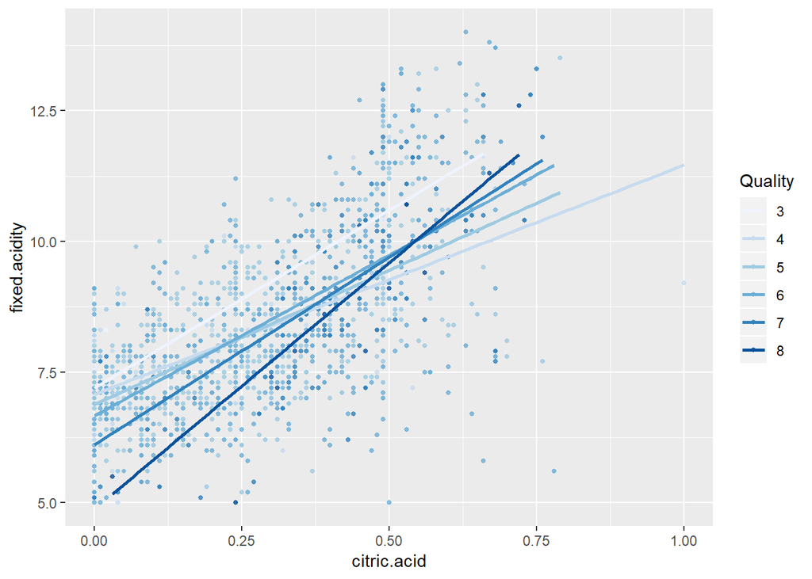

No strong relationship between acidity and the quality is observed here.

# Multivariate Analysis

The investigation shows the following combinations would produce better wine: high alcohol percent with low volatile acidity; high alcohol percent with high sulphates amount; high alcohol percent with low pH level; high alcohol percent with high citric acid level.

# Final Plots and Summary

### Plot One

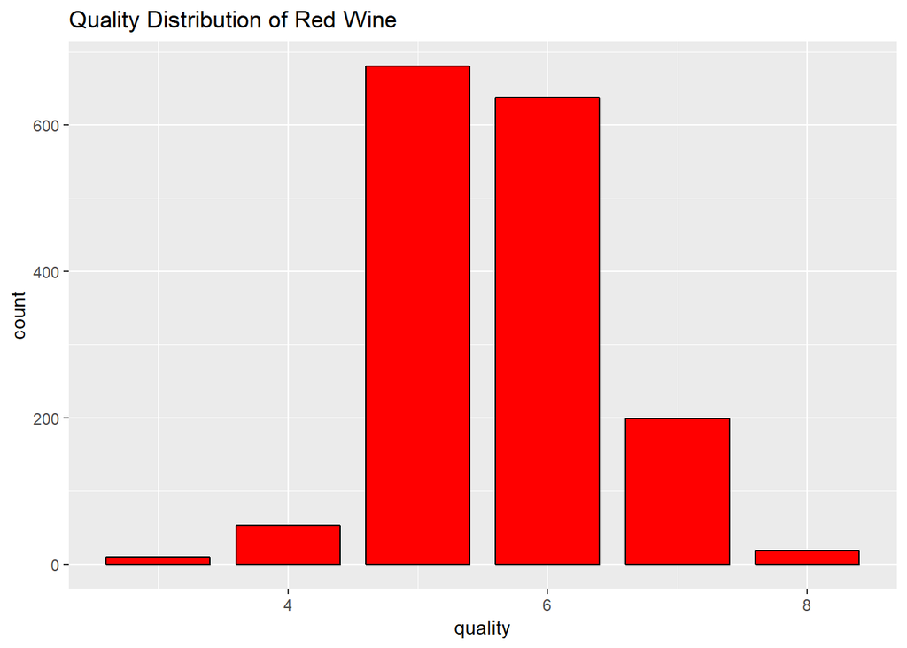

### Description One

We can see from this plot that most wines have a quality of 5, 6 or 7. The dataset is centralized towards red wines of average quality.

### Plot Two

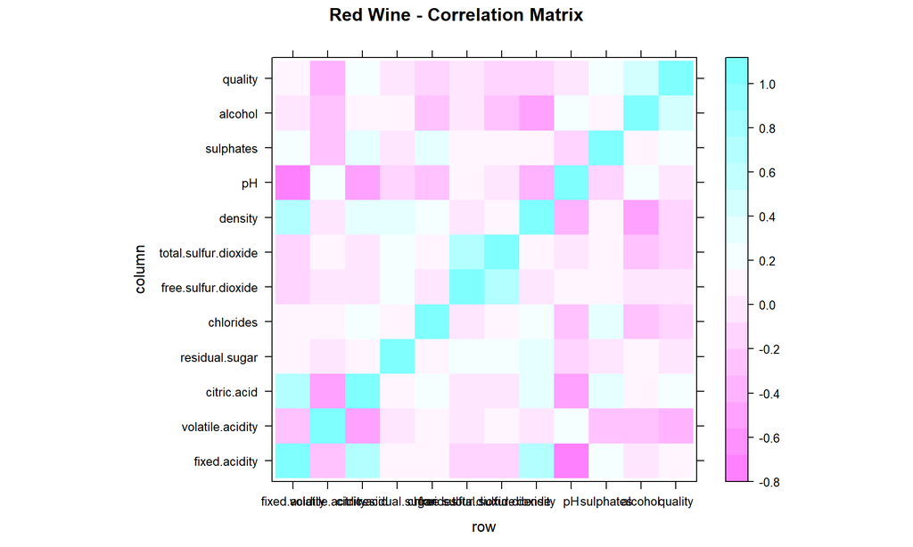

### Description Two

The correlation matrix is a great way to visualize the correlations between two variables. From the plot, we can see that quality is mostly affected by alcohol and volatile acidity.

### Plot Three

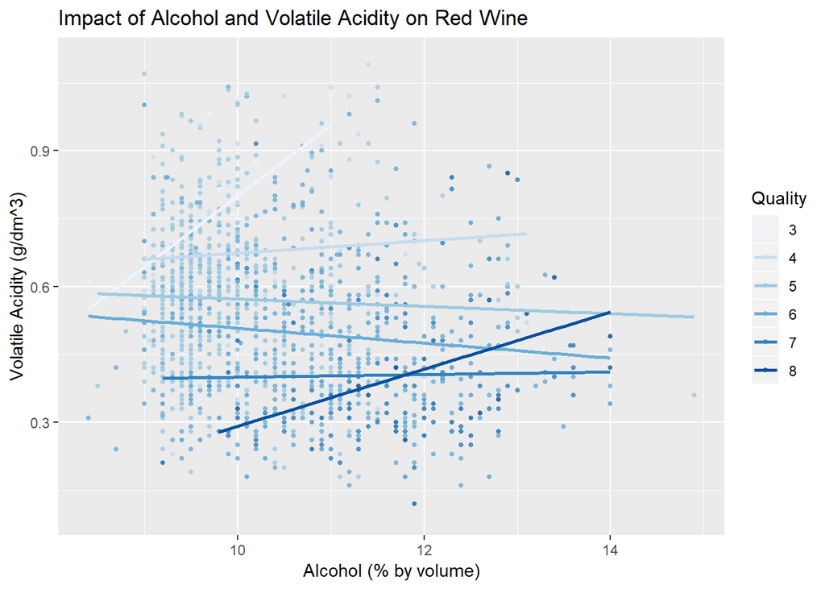

### Description Three

The previous plot shows alcohol and volatile acidity are the two properties that have strong impact on quality. This plot investigates what happens when these two chemicals are put together. We see that the combination of high alcohol content and low level of volatile avidity would produce wines of higher quality.

# Reflection

One struggle that I went through was to decide on the combination of chemicals to investigate. It is easy to spot the correlation between quality and one single chemical attribute. However, it is difficult to study the impact on quality with more than one chemical. Due to limited time and resources, the maximum number of chemicals in each analysis was two. However, what happens when more than two chemicals are combined together? What would be their impact on quality? Also, in biviariate analysis, I focused on the variables with strong correlations with quality and studied their impact. However, if two chemical proerties both have low correlations on wine quality, when combined together, they may produce a strong influence.This scenario wasn’t further explored.

One success that I encountered was the correlation matrix that I created. The pandoc table is helpful but it is much easier and interesting to visualize the relationships on the plot!

For the future, it would be beneficial to include more data on wines with extreme ratings. The current data is centralized towards average ratings of 5,6 and 7. In my opinion, including more samples of “bad wine”" (rating of 1 to 4) and “good wine” (rating of 8 to 10) would make the invesigation results of chemical properties on wine quality much more convincing. Also, in addition to chemical properties, other factors such as wine age, ripeness and flavor of the grapes also affect the taste and quality of the wine. Adding these variables can make the analysis more complete.